# Reproducible Research: Peer Assessment 1

# Introduction

It is now possible to collect a large amount of data about personal movement using activity monitoring devices such as a Fitbit, Nike Fuelband, or Jawbone Up. These type of devices are part of the “quantified self” movement – a group of enthusiasts who take measurements about themselves regularly to improve their health, to find patterns in their behavior, or because they are tech geeks. But these data remain under-utilized both because the raw data are hard to obtain and there is a lack of statistical methods and software for processing and interpreting the data.

This assignment makes use of data from a personal activity monitoring device. This device collects data at 5 minute intervals through out the day. The data consists of two months of data from an anonymous individual collected during the months of October and November, 2012 and include the number of steps taken in 5 minute intervals each day.

# Data

The data for this assignment can be downloaded from the course web site:

- Dataset: [Activity monitoring data](https://d396qusza40orc.cloudfront.net/repdata%2Fdata%2Factivity.zip) [52K]

The variables included in this dataset are:

- **steps**: Number of steps taking in a 5-minute interval (missing values are coded as NA)
- **date**: The date on which the measurement was taken in YYYY-MM-DD format
- **interval**: Identifier for the 5-minute interval in which measurement was taken

The dataset is stored in a comma-separated-value (CSV) file and there are a total of 17,568 observations in this dataset.

# Performed analysis

In this section you will find the description of the questions and the explanations and the code used in order to answer them.

## Environment settings

My first step was to change the locale into English and load some libraries that I found I was going to need. I setted the working directory too, but I found it was pointless to add the code for my directory. If you are going to execute this in your computer, just remember to set the working directory pointing where you have downloaded the data.

```r
Sys.setlocale("LC_ALL","en_GB.UTF-8");
library("dplyr");
```

## Loading and preprocessing the data

**1. Load the data**

**2. Process/transform the data (if necessary) into a format suitable for your analysis**

I load the data into a format suitable for the analysis. The original file is unzipped and loaded into *activityData* variable.

```r
untar('activity.zip');
activityData <- read.csv('activity.csv', header = TRUE, sep = ",");
```

## What is mean total number of steps taken per day?

**1. Calculate the total number of steps taken per day.**

I use the *aggregate()* function to sum the steps, grouping by date. The result is saved into *sumStepsByDate*. Then, I change the names of the columns of this variable into a more meaningful ones.

```r
sumStepsByDate <- aggregate(activityData$steps, by=activityData["date"], FUN=sum);
names(sumStepsByDate) <- c("date","sumsteps");
```

**2. Make a histogram of the total number of steps taken each day**

This is performed using the function *hist()* over the sum of the steps.

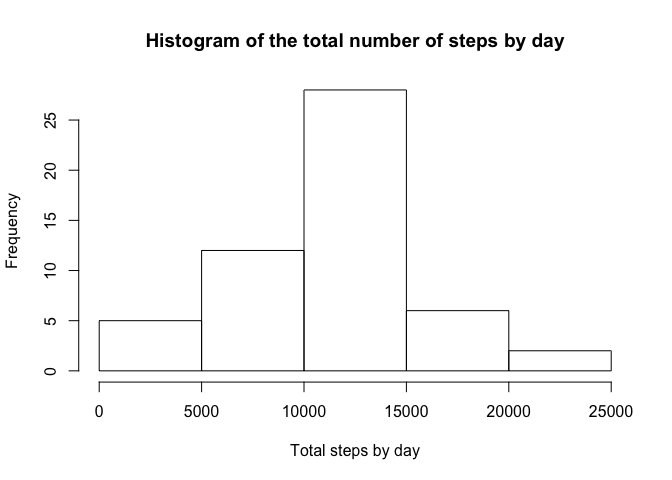

```r
hist(sumStepsByDate$sumsteps, main="Histogram of the total number of steps by day",
     xlab="Total steps by day");
```

**3. Calculate and report the mean and median of the total number of steps taken per day**

Using *mean()* and *median()* functions.

```r
mean(sumStepsByDate$sumsteps, na.rm = TRUE);
```

```
## [1] 10766.19
```

```r
median(sumStepsByDate$sumsteps, na.rm = TRUE);
```

```
## [1] 10765
```

## What is the average daily activity pattern?

**1. Make a time series plot of the 5-minute interval (x-axis) and the average number of steps taken, averaged across all days (y-axis)**

I use the *aggregate()* function to calculate the mean of the steps, grouping by interval. The result is saved into *avgStepsByInterval*. Then, I change the names of the columns of this variable into a meaningful ones. Third, I use the Base plotting system plot function to show the mean of steps taken in each 5-minute interval.

```r
avgStepsByInterval <- aggregate(activityData$steps, by=activityData["interval"], FUN=mean, na.rm = TRUE);
names(avgStepsByInterval) <- c("interval","avgsteps");
```

It’s interesting to see, as was pointed in the course forum (see [this post](https://class.coursera.org/repdata-015/forum/thread?thread_id=19)), that if the intervals are used as the x-axis, the plot system assumes that there are missing values. This is because the intervals are used as numbers, but instead they are the times of the day. So, for the plotting system there is a kind of “gap” between the intervals 55 and 100, 155 and 200, etc, when there is no such a gap, as 55 means 0:55am, 100 is 1:00am, etc. The plotting system treat the interval like a numeric value and fill the gaps, plotting weird intervals like 1:70am and so.

In order to avoid this, some functions are used in the next chunk code. First, inside the plot function, the values for the x axis are changed to be dates. This is performed using *sprintf()*, to pad with 0 the interval to a 4-digit integer and then *strptime()* is used, telling to this function that the format is “HHMM”. This gives as a result a date-hour list of values, with the date of the execution used for the part day-year-month of the date. This is not really a problem, because I don’t want the date part of the result, only the time (hour and minutes). Additionally, in the *plot()* function we add the *xaxt = n* parameter, in order to not show the x-axis, avoiding a wrong interpretation of the axis values. The correct data values for the axis are calculated using *range()* and applied to the plotted axis by *axis.POSIXct()*. The *at* parameter is a sequence from the first element to the last, in increments of 300, being this increments of 300 seconds (5min * 60s = 300s). This part of the procedure is much like the example in the help page for *axis.POSIXct()* function.

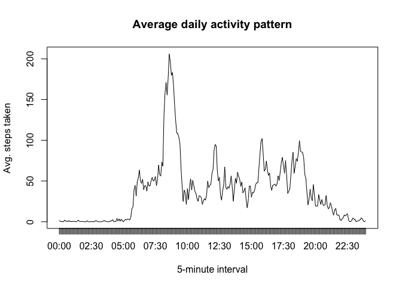

```r
with(avgStepsByInterval, {
    plot(strptime(sprintf("%04d",as.numeric(avgStepsByInterval$interval)),"%H%M"),
         avgStepsByInterval$avgsteps,
         type="l",
         xlab="5-minute interval",
         ylab="Avg. steps taken",
         main="Average daily activity pattern",
         xaxt = "n");
    axisInterval <- as.POSIXct(range(strptime(sprintf("%04d",as.numeric(avgStepsByInterval$interval)),"%H%M")));
    axis.POSIXct(1, at = seq(axisInterval[1], axisInterval[2], by = 300), format = "%H:%M");
});
```

**2. Which 5-minute interval, on average across all the days in the dataset, contains the maximum number of steps?**

To find this I use the *max()* function in the average steps value and do subsetting looking for the corresponding interval.

```r
avgStepsByInterval$interval[avgStepsByInterval$avgsteps == max(avgStepsByInterval$avgsteps)];
```

```
## [1] 835
```

## Imputing missing values

Note that there are a number of days/intervals where there are missing values (coded as NA). The presence of missing days may introduce bias into some calculations or summaries of the data.

**1. Calculate and report the total number of missing values in the dataset (i.e. the total number of rows with NAs)**

I do this using the *sum()* function to count the steps whose value is NA.

```r
sum(is.na(activityData$steps));
```

```
## [1] 2304
```

**2. Devise a strategy for filling in all of the missing values in the dataset. The strategy does not need to be sophisticated. For example, you could use the mean/median for that day, or the mean for that 5-minute interval, etc.:**

Taking a look at the data, we can observe that there are 288 different intervals for each date, corresponding to (24h * 60m) / 5-minute intervals = 288 intervals per day. So, there are no missing data in the intervals. As is said above, the intervals are the time of the measure (i.e. interval 635 means 6:35am).

Also, it can be observed that the NAs are all concentrated in eight days and more, when there is a NA in a specific day, all the values of the day are NAs. I decided to fill the missing values for this days with the average of each corresponding 5-minute interval, this is, the average value for this intervals over all the other days without NAs.

```r
length(unique(activityData$interval));
```

```
## [1] 288
```

```r
table(activityData$date[is.na(activityData$steps)]);
```

```
##
## 2012-10-01 2012-10-02 2012-10-03 2012-10-04 2012-10-05 2012-10-06
##        288          0          0          0          0          0
## 2012-10-07 2012-10-08 2012-10-09 2012-10-10 2012-10-11 2012-10-12
##          0        288          0          0          0          0
## 2012-10-13 2012-10-14 2012-10-15 2012-10-16 2012-10-17 2012-10-18
##          0          0          0          0          0          0
## 2012-10-19 2012-10-20 2012-10-21 2012-10-22 2012-10-23 2012-10-24
##          0          0          0          0          0          0
## 2012-10-25 2012-10-26 2012-10-27 2012-10-28 2012-10-29 2012-10-30
##          0          0          0          0          0          0
## 2012-10-31 2012-11-01 2012-11-02 2012-11-03 2012-11-04 2012-11-05
##          0        288          0          0        288          0
## 2012-11-06 2012-11-07 2012-11-08 2012-11-09 2012-11-10 2012-11-11
##          0          0          0        288        288          0
## 2012-11-12 2012-11-13 2012-11-14 2012-11-15 2012-11-16 2012-11-17
##          0          0        288          0          0          0
## 2012-11-18 2012-11-19 2012-11-20 2012-11-21 2012-11-22 2012-11-23
##          0          0          0          0          0          0
## 2012-11-24 2012-11-25 2012-11-26 2012-11-27 2012-11-28 2012-11-29
##          0          0          0          0          0          0
## 2012-11-30
##        288
```

**3. Create a new dataset that is equal to the original dataset but with the missing data filled in:**

The process starts making a copy of the original data into *activityDataNAsFilled*. Then, a copy of the data with NAs is made in *activityDataNAs*. Using the *merge()* function it’s possible to add each average value to its corresponding data row. The common column for the merge is the interval. The result is merged into *activityDataNAsFilled* and ordered using the *arrange()* function. The NAs values in *steps* are replaced by the average value and the extra column is deleted using *subset()*.

```r
activityDataNAsFilled <- activityData;
activityDataNAs <- activityData[is.na(activityData$steps),];
activityDataNAs <- merge(activityDataNAs,avgStepsByInterval);
activityDataNAsFilled <- arrange(merge(activityDataNAsFilled,activityDataNAs, all = TRUE), date, interval);
activityDataNAsFilled$steps[is.na(activityDataNAsFilled$steps)] <-
    activityDataNAsFilled$avgsteps[is.na(activityDataNAsFilled$steps)];
activityDataNAsFilled <- subset(activityDataNAsFilled, select = c("steps","date","interval"));
```

**4. Make a histogram of the total number of steps taken each day and Calculate and report the mean and median total number of steps taken per day. Do these values differ from the estimates from the first part of the assignment? What is the impact of imputing missing data on the estimates of the total daily number of steps?**

From *activityDataNAsFilled*, I use the *aggregate()* function to calculate the sum of the steps grouping by date. Then, I change the names of the columns into a more meaningful ones. The histogram is made with *hist()* and *mean()* and *median()* functions are used.

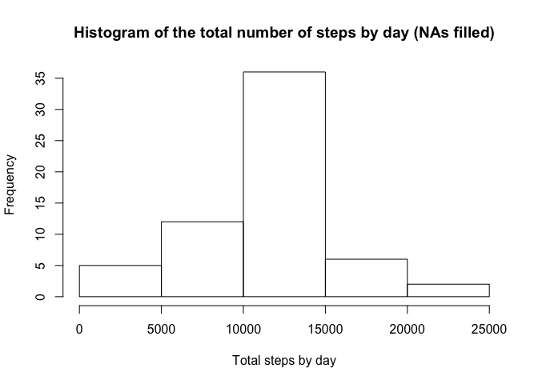

```r
sumStepsByDateNAsFilled <- aggregate(activityDataNAsFilled$steps, by=activityDataNAsFilled["date"], FUN=sum);
names(sumStepsByDateNAsFilled) <- c("date","sumsteps");
hist(sumStepsByDateNAsFilled$sumsteps, main="Histogram of the total number of steps by day (NAs filled)",
     xlab="Total steps by day");
```

```r
mean(sumStepsByDateNAsFilled$sumsteps);
```

```
## [1] 10766.19
```

```r
median(sumStepsByDateNAsFilled$sumsteps);
```

```
## [1] 10766.19
```

As I filled the NAs with the mean value for each interval, the mean takes the same value than the previous calculation, when ignoring NAs. The median value is slightly higher and now it’s the same as the mean. The frequencies of the histogram are raised, as some values are now more repeated.

## Are there differences in activity patterns between weekdays and weekends?

For this part the weekdays() function may be of some help here. Use the dataset with the filled-in missing values for this part.

**1. Create a new factor variable in the dataset with two levels – “weekday” and “weekend” indicating whether a given date is a weekday or weekend day.**

This is performed using the *factor()* function to encode the weekdays as an ordered factor. Then, the *levels()* function is used to sort each day into two categories: “weekday” or “weekend”.

```r
activityDataNAsFilled$weekday <- weekdays(as.Date(activityDataNAsFilled$date));
activityDataNAsFilled$weekday <- factor(weekdays(as.Date(activityDataNAsFilled$date)), levels=c("Monday", "Tuesday", "Wednesday", "Thursday", "Friday", "Saturday", "Sunday"), ordered = TRUE);
levels(activityDataNAsFilled$weekday) <- list(weekday = c("Monday", "Tuesday", "Wednesday", "Thursday", "Friday"), weekend = c("Saturday", "Sunday"));
```

**2. Make a panel plot containing a time series plot (i.e. type = “l”) of the 5-minute interval (x-axis) and the average number of steps taken, averaged across all weekday days or weekend days (y-axis). See the README file in the GitHub repository to see an example of what this plot should look like using simulated data.**

The average by interval and weekday is made using *aggregate()* and the names are changed. The layout is divided setting *par(mfrow = …)* into two rows and one column. The newly created column *weekday* is used to split the data between the two graphics. Finally, the plots are drawed using the Base plotting system plot function.

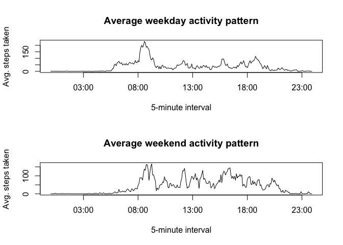

```r
avgStepsByIntervalNAsFilled <- aggregate(activityDataNAsFilled$steps,
                                         by=activityDataNAsFilled[c("interval","weekday")], FUN=mean, na.rm = TRUE);
names(avgStepsByIntervalNAsFilled) <- c("interval","weekday","avgsteps");

par(mfrow = c(2,1));
with(avgStepsByIntervalNAsFilled, {
    x <- strptime(sprintf("%04d",as.numeric(
            avgStepsByIntervalNAsFilled$interval[avgStepsByIntervalNAsFilled$weekday == "weekday"]
            )),"%H%M");
    y <- avgStepsByIntervalNAsFilled$avgsteps[avgStepsByIntervalNAsFilled$weekday == "weekday"];

    plot(x, y, type="l",
         xlab="5-minute interval",
         ylab="Avg. steps taken",
         main="Average weekday activity pattern");

    x <- strptime(sprintf("%04d",as.numeric(
            avgStepsByIntervalNAsFilled$interval[avgStepsByIntervalNAsFilled$weekday == "weekend"]
            )),"%H%M");
    y <- avgStepsByIntervalNAsFilled$avgsteps[avgStepsByIntervalNAsFilled$weekday == "weekend"];

    plot(x, y, type="l",
         xlab="5-minute interval",
         ylab="Avg. steps taken",
         main="Average weekend activity pattern");

});
```

The graphs show that in weekdays the steps are more concentrated in some intervals and in weekends the steps are more fairly distributed along the intervals.